# Wines of the PNW

Author

Kayle Megginson

Published

January 27, 2025

*DATA 505 HW #2* **Kayle Megginson February 2nd 2025**

**Abstract:**

This is a technical blog post of **both** an HTML file *and* .qmd file hosted on GitHub pages.

# Setup

**Step Up Code:**

```r
library(tidyverse)
library(caret)
library(fastDummies)
wine <- readRDS(gzcon(url("https://github.com/cd-public/D505/raw/master/dat/wine.rds")))
```

**Explanataion:**  
Line 1: `library(tidyverse)`: Loads the Tidyverse, a collection of R packages for data manipulation and visualization.  
Line 2: `library(caret)`: Loads the Caret package for machine learning tasks.  
Line 3: `library(fastDummies)`: Loads the fastDummies package to create dummy variables efficiently.  
Line 4: `wine <- readRDS(...)`: Reads in the `wine.rds` dataset from a remote GitHub repository.

# Feature Engineering

We begin by engineering an number of features.

1. Create a total of 10 features (including points).
2. Remove all rows with a missing value.
3. Ensure only log(price) and engineering features are the only columns that remain in the `wino` dataframe.

```r
wino <- wine %>%
  mutate(
    lprice = log(price),
    vintage = year,
    is_us_wine = ifelse(country == "US", 1, 0),
    name_length = nchar(title),
    description_length = nchar(description),
    region_count = (!is.na(region_1)) + (!is.na(region_2)),
    has_designation = ifelse(!is.na(designation), 1, 0),
    has_taster = ifelse(!is.na(taster_name), 1, 0),
    price_per_point = price / (points + 1),
    province_count = as.integer(as.factor(province))
  ) %>%
  select(lprice, points, vintage, is_us_wine, name_length, description_length,
         region_count, has_designation, has_taster, price_per_point, province_count) %>%
  drop_na()
```

# Caret

We now use a train/test split to evaluate the features.

1. Use the Caret library to partition the wino dataframe into an 80/20 split.
2. Run a linear regression with bootstrap resampling.
3. Report RMSE on the test partition of the data.

```r
# Partition data into 80% training and 20% testing
set.seed(42)
train_index <- createDataPartition(wino$lprice, p = 0.8, list = FALSE)
train_data <- wino[train_index, ]
test_data <- wino[-train_index, ]

# Train a linear regression model
fit_control <- trainControl(method = "boot", number = 50)
model <- train(lprice ~ ., data = train_data, method = "lm", trControl = fit_control)

# Predict on test data and calculate RMSE
predictions <- predict(model, test_data)
rmse_value <- RMSE(predictions, test_data$lprice)

rmse_value
```

```
[1] 0.3892879
```

We recieve an output of 0.3892879 as our RMSE value

# Variable selection

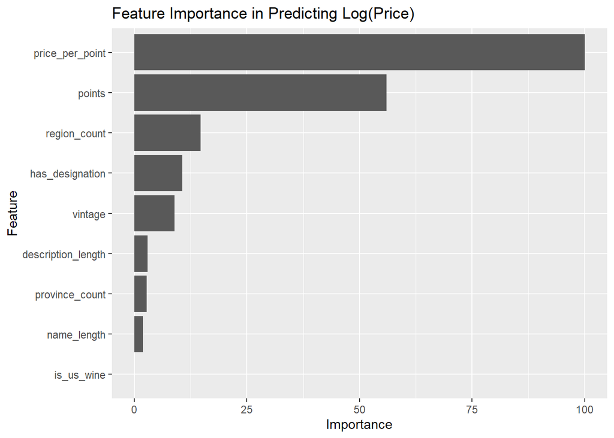

```r
# Extract feature importance
importance <- varImp(model)

# Plot feature importance
ggplot(importance) +
  ggtitle("Feature Importance in Predicting Log(Price)")
```